# MetadataDistributions_v1

MSBR

2023-12-12

#### Introduction

It is common in both single-cell and NICHES connectomic data analysis to want to inquire about how certain metadat slots are distributed against other metadata categorizations. I.e.

“How are different experimental conditions distributed across cell type clusters?”

or

“How are different cell types distributed across different experimental conditions?”

or

“How are different cell types distributed across different CellToCell signaling archetypes?”

These questions are easy to answer from the source object metadata. However, if these quanitifications are done without bootstrapping, then the answers to the above questions yield single values upon which no statistical analysis can be done. This is terrible! We have so much data! We should leverage it!

This vignette details the development of a generalizable function to analyze metadata category distributions and to be able to calcualte statistical significance(s), if desired.

There are four major tasks in play:

1. We must subsample the input data thoughtfully and intelligently to minimize artifact
2. Perform requested calculations
3. We must store the data in a format that allows easy and flexible ggplotting
4. We must create beautiful and flexible ggplots that can be customized by the user

For ease of engineering, let’s bundle each of these tasks into their own dedicated function which we can daisy-chain together later.

#### 1. Create a well-organized list of downsampled objects for bootstrapping

First, let’s load some demo data. We want something that has multiple conditions or samples and multiple cell types so that we can play these different metadata categorizations against one another. Let’s use:

```r
require(Seurat)
require(SeuratData)
require(cowplot)
require(ggplot2)
#InstallData('ifnb')
data("ifnb")
?ifnb
```

First, let’s inspect the metadata to make sure that this dataset suits our needs:

```r
table(ifnb$seurat_annotations,ifnb$stim)
```

```
##
##                CTRL STIM
##   CD14 Mono    2215 2147
##   CD4 Naive T   978 1526
##   CD4 Memory T  859  903
##   CD16 Mono     507  537
##   B             407  571
##   CD8 T         352  462
##   T activated   300  333
##   NK            298  321
##   DC            258  214
##   B Activated   185  203
##   Mk            115  121
##   pDC            51   81
##   Eryth          23   32
```

Perfect.

Take a look at the UMAP, for fun?

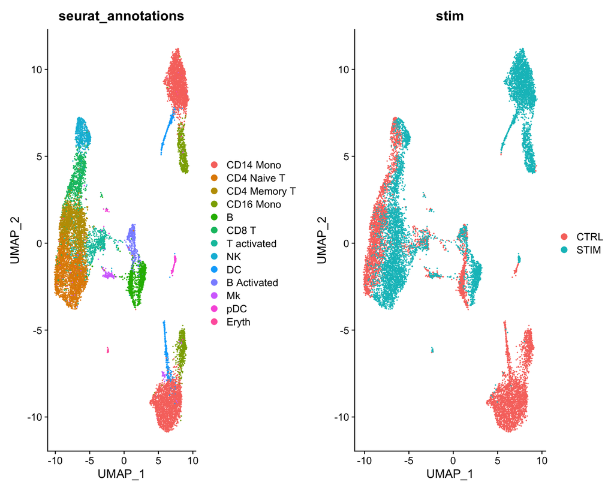

```r
ifnb <- ScaleData(ifnb)
ifnb <- FindVariableFeatures(ifnb)
ifnb <- RunPCA(ifnb,npcs = 50)
ifnb <- RunUMAP(ifnb,dims=1:30)
p1 <- DimPlot(ifnb, group.by = 'seurat_annotations')
p2 <- DimPlot(ifnb, group.by = 'stim')
plot_grid(p1,p2)
```

```r
MetadataDist <- function(object,
                         metadata.1,
                         metadata.2,
                         chunks = 10){

  ### TASK 1: Break into bootstrapped samples (without replacement, so no measurement is used more than once)
  # First, let's break the object into the number of chunks
  num.cells.per.chunk <- ceiling(ncol(object)/chunks)
  message(paste('Breaking input object into',chunks,'chunks of approximately',num.cells.per.chunk,'cells each...'))
  # Create a new metadata slot that divvies the input into bootstrapped samples
  bootstrap <- c()
  for(i in 1:chunks){
    bootstrap <- c(bootstrap, rep(paste('Sample',i,sep = "_"),num.cells.per.chunk))
  }
  # remove remaining one cell at the end
  bootstrap <- bootstrap[1:length(bootstrap)-1]
  # check that the length is right
  length(bootstrap) == ncol(object)
  #table(bootstrap)
  # randomize the order completely
  bootstrap <- sample(bootstrap)
  # add to object to use for subsetting
  object$bootstrap <- bootstrap
  split <- SplitObject(object,split.by = 'bootstrap')

  ### TASK 2-3: perform requested calculations and store nicely
  dist.data <- data.frame()
  for(i in 1:length(split)){

    # create metadata distribution table
    temp <- table(split[[i]]@meta.data[[metadata.1]],split[[i]]@meta.data[[metadata.2]])

    # normalize so that all values of metadata.2 for a given metadata.1 add up to 1
    for(j in 1:nrow(temp)){
      temp[j,] <- temp[j,]/rowSums(temp)[j]
    }
    # rowSums(temp) # should all equal 1
    # convert to data frame
    temp <- as.data.frame(temp)
    # add sample ID
    temp$bootstrap <- names(split[i])
    # concatenate
    dist.data <- rbind(dist.data,temp)
  }

  #View(dist.data)

# Provide function outputs
return(dist.data)
}
```

Now let’s test it by making some plots. First, let’s do stim vs. cell type:

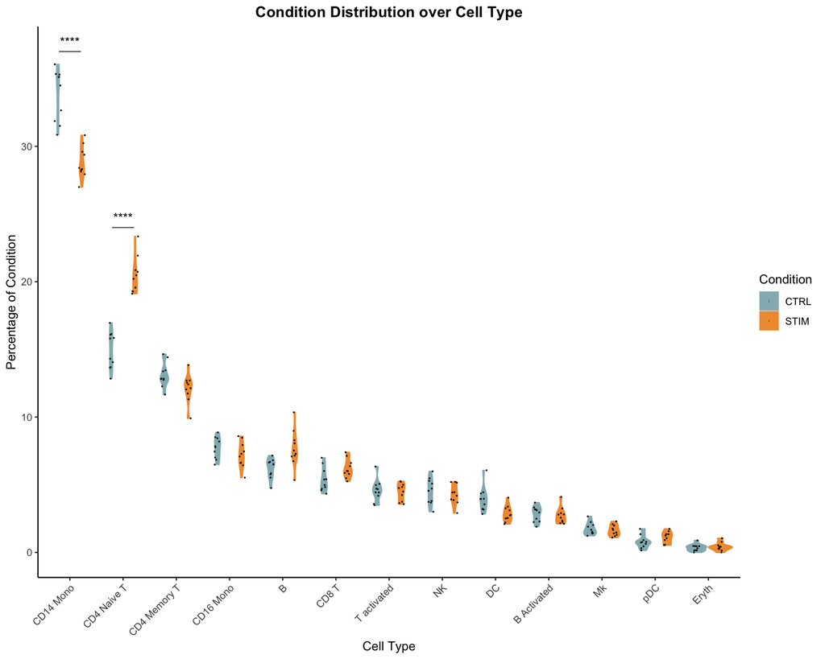

```r
dist.data <- MetadataDist(object = ifnb,
             metadata.1 = 'stim',
             metadata.2 = 'seurat_annotations',
             chunks = 10)

  ### TASK 4: make pretty ggplots
  # see https://rpkgs.datanovia.com/ggpubr/reference/geom_pwc.html for stats code
  require(ggplot2)
  require(ggpubr)
  colors.use <- c('#93B7BE','#F19A3E','#3D3B8E','#E072A4',"#B22222","grey","#A034F0",'yellow','#8B786D','green','violet','red','blue','#00BFB2')
output.plot.1 <-  ggplot(data = dist.data,
           aes(x = Var2,y=Freq*100,fill=Var1,color=Var1))+
      geom_violin()+
      geom_point(position = position_jitterdodge(dodge.width = 0.9,jitter.width=0.25),size=0.1,color='black')+
      theme_classic()+
      ggtitle('Condition Distribution over Cell Type')+
      ylab('Percentage of Condition')+
      xlab('Cell Type')+
      theme(axis.text.x = element_text(angle = 45, vjust = 1, hjust=1),
            plot.title = element_text(face = "bold",hjust = 0.5))+
      geom_pwc(
        aes(group = Var1),
        remove.bracket = F,
        tip.length = 0,
        method = "t_test",
        label = "{p.adj.signif}",
        y.position = c(37,24,10),
        #label = "{p.adj.format}{p.adj.signif}",
        p.adjust.method = "bonferroni",
        p.adjust.by = "panel",
        hide.ns = TRUE)+
      guides(fill=guide_legend(title="Condition"))+
      guides(color=guide_legend(title="Condition"))+
      scale_fill_manual(values = colors.use)+
      scale_color_manual(values = colors.use)
output.plot.1
```

And if we reverse the ordering, and remake the plot to look good:

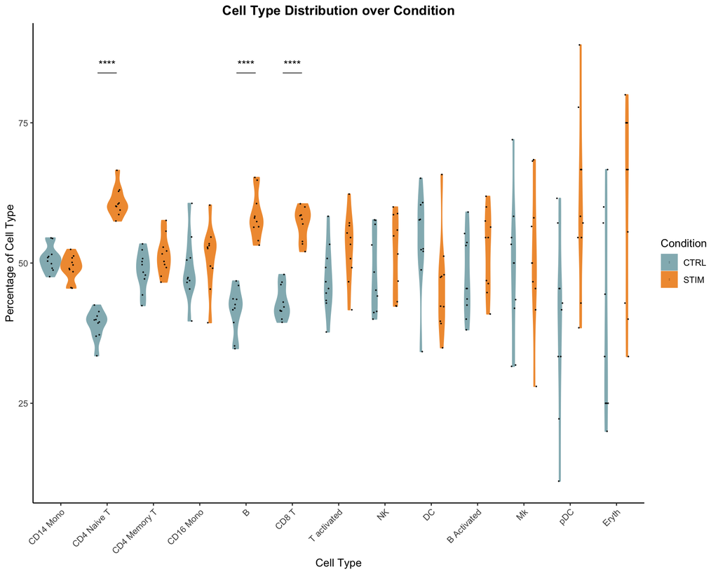

```r
dist.data <- MetadataDist(object = ifnb,
             metadata.1 = 'seurat_annotations',
             metadata.2 = 'stim',
             chunks = 10)

  ### TASK 4: make pretty ggplots
  # see https://rpkgs.datanovia.com/ggpubr/reference/geom_pwc.html for stats code
  require(ggplot2)
  require(ggpubr)
  colors.use <- c('#93B7BE','#F19A3E','#3D3B8E','#E072A4',"#B22222","grey","#A034F0",'yellow','#8B786D','green','violet','red','blue','#00BFB2')
output.plot.2 <-  ggplot(data = dist.data,
           aes(x = Var1,y=Freq*100,fill=Var2,color=Var2))+
      geom_violin()+
      geom_point(position = position_jitterdodge(dodge.width = 0.9,jitter.width=0.25),size=0.1,color='black')+
      theme_classic()+
      ggtitle('Cell Type Distribution over Condition')+
      ylab('Percentage of Cell Type')+
      xlab('Cell Type')+
      theme(axis.text.x = element_text(angle = 45, vjust = 1, hjust=1),
            plot.title = element_text(face = "bold",hjust = 0.5))+
      geom_pwc(
        aes(group = Var2),
        remove.bracket = F,
        tip.length = 0,
        method = "t_test",
        label = "{p.adj.signif}",
        y.position = 80,
        #label = "{p.adj.format}{p.adj.signif}",
        p.adjust.method = "bonferroni",
        p.adjust.by = "panel",
        hide.ns = T)+
      guides(fill=guide_legend(title="Condition"))+
      guides(color=guide_legend(title="Condition"))+
      scale_fill_manual(values = colors.use)+
      scale_color_manual(values = colors.use)
output.plot.2
```

Thoughts?